# Simple Linear Regression

```r
credit <- read.csv("C:/Users/Jim/Desktop/MATH 325/Math 325 Notebook/Data/credit.csv")
```

Click to read the prologue

## Background

Does the number of credits a student takes in a single semester impact their GPA?  
My theory is that even though more credits makes it harder to get good grades, the students who take more credits will have a higher GPA because they are more serious about their studies. I will see.  
I surveyed 15 single male students from two neighboring apartments: Quincy House A and Quincy House B. They were asked these two questions:  
The last semester/term in which you took at least one course, how many credits did you take?  
What was you GPA for those credits?  
This is the result:

```r
pander(credit)
```

| student | apartment | credit | gpa |
| --- | --- | --- | --- |
| 1 | B | 12 | 1.6 |
| 2 | B | 12 | 3.5 |
| 3 | B | 17 | 3.856 |
| 4 | B | 2 | 3 |
| 5 | B | 12 | 3.675 |
| 6 | B | 6 | NA |
| 7 | A | 12 | 4 |
| 8 | A | 18 | 3.5 |
| 9 | A | 12 | 3.7 |
| 10 | A | 11 | 3.1 |
| 11 | A | 14 | 4 |
| 12 | A | 14.5 | 3.871 |
| 13 | A | 3 | 3.7 |
| 14 | A | 12 | NA |
| 15 | A | 0.5 | 3.8 |

The students are labeled in the order they were surveyed.  
Students 6 and 14 did not provide a GPA.  
Student 15 provided an estimated average.  
There is a 10th resident of apartment A, whom I did not meet.  
I will be using the 13 complete measurements.

## Analysis

I am using linear regression in attempt to describe the relationship.
$$Y_i = \beta_0 + \beta_1 X_i + \epsilon_i$$

In the above equation:  
$Y_i$ is the GPA.  
$X_i$ is the number of credits.  
$\beta_1$ is the slope of the regression relation.  
$\beta_0$ is the Y-intercept, the base height of the line.  
$\epsilon_i$ is the error term, the distance $Y_i$ falls from the line.

Hypothesis statement:

$$H_0:β_1=0$$
$$H_a:β_1≠0$$
I will use a confidence level of 0.90 ($\alpha=0.1$).
I want to look at the plot first:

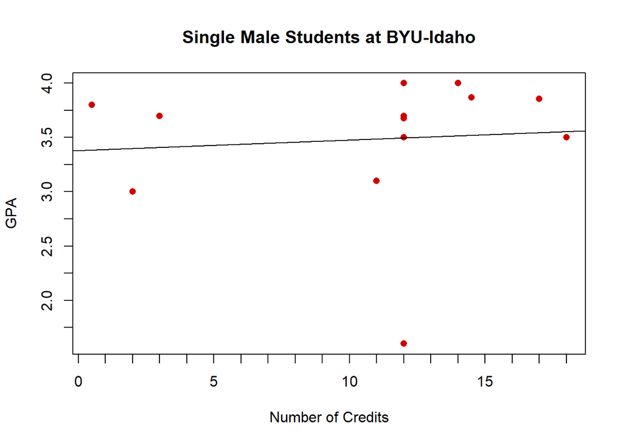

```r
plot(gpa ~ credit, data=credit, pch=16, col="#D00000", xlab="Number of Credits", ylab="GPA", main="Single Male Students at BYU-Idaho")
minor.tick(nx=5, tick.ratio=1)
credit.lm <- lm(gpa ~ credit, data=credit)
abline(credit.lm)
```

```r
#pander(credit.lm)
```

With only 13 points, I need to know that the residuals follow a normal distribution to make use of the model.

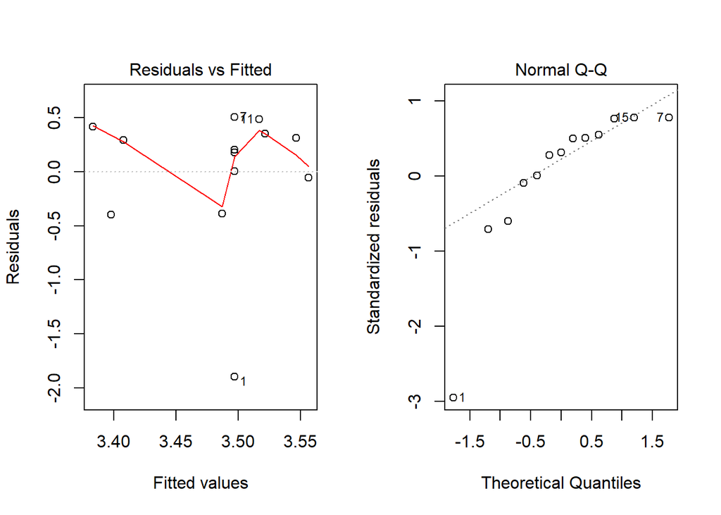

```r
par(mfrow=c(1,2))
plot(credit.lm, which=2:1)
```

The residuals are not normal, and the variance is not constant either.  
This seems to be mostly due to the outlier, so I’ll see what it is like without it:

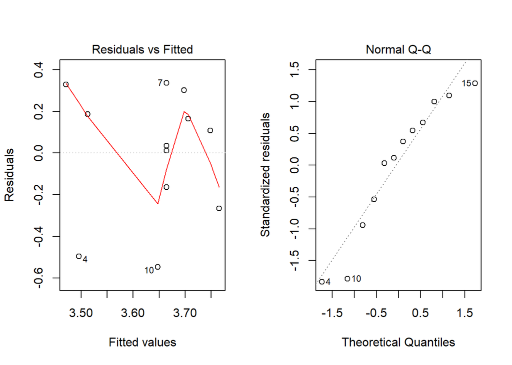

```r
par(mfrow=c(1,2))
credit12 <- subset(credit, student!="1")
credit12.lm <- lm(gpa ~ credit, data=credit12)
plot(credit12.lm, which=2:1)
```

The variance appears constant now, but the residuals still are not normal enough. Also, the observations do not seem independent.  
This is the linear model without the outlier:

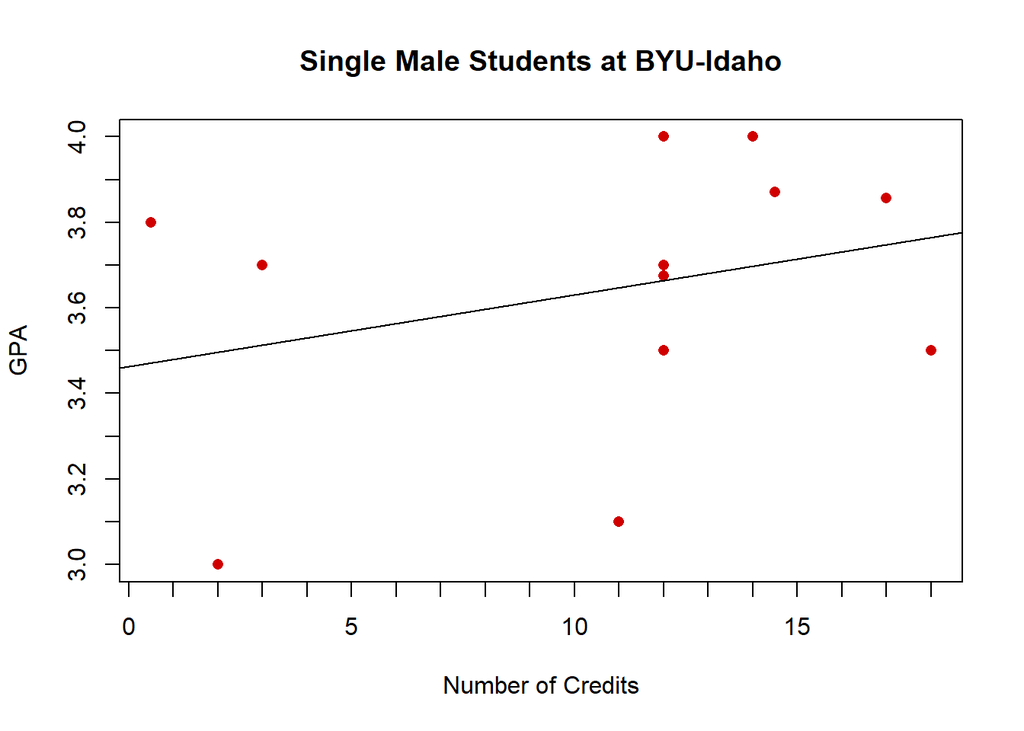

```r
plot(gpa ~ credit, data=credit12, pch=16, col="#D00000", xlab="Number of Credits", ylab="GPA", main="Single Male Students at BYU-Idaho")
minor.tick(nx=5, tick.ratio=1)
abline(credit12.lm)
```

Below is the statistical summary for the linear model without the outlier. The “credit” row of the table gives the details of $\beta_1$ (the slope).

```r
pander(credit12.lm)
```

Fitting linear model: gpa ~ credit

|  | Estimate | Std. Error | t value | Pr(>\|t\|) |
| --- | --- | --- | --- | --- |
| **(Intercept)** | 3.462 | 0.202 | 17.14 | 9.621e-09 |
| **credit** | 0.01682 | 0.01682 | 1 | 0.3408 |

Note that the last column shows the P-value is at 0.34.

## Interpretation

There could be a very small positive relationship, matching my original guess. However, the P-value for the slope is rather insignificant and the requirements were not closely met for this test. For this reason, I cannot reject the null hypothesis that the number of credits a student takes in a semester and their GPA are independent.

I’ve run out of cake.